# Lexical Recall Analysis (study1adults)

Adam Stone, PhD

10-09-2017

# Re-Initializing

This assumes you’ve already done 01dataimportclean and so there’ll be a nice new .csv file to re-import here. Also we gotta import all the libraries again.

```r
# Import packages we'll need.
library(tidyverse)
library(stringr)
library(lme4)
library(lmerTest)
library(prettydoc)
library(broom)
library(knitr)
library(xtable)
library(kableExtra)
options(knitr.table.format = "html")
data <- read_csv('cleandata.csv',col_types =
                   cols(.default = col_double(),
                        id = col_integer(),
                        participant = col_character(),
                        hearing = col_character(),
                        videogroup = col_character(),
                        aoagroup = col_character(),
                        languagegroup = col_character(),
                        maingroup = col_character(),
                        video = col_character(),
                        story = col_character(),
                        direction = col_character(),
                        aoasl = col_integer(),
                        acc = col_double(),
                        forehead = col_double(),
                        eyes = col_double(),
                        mouth = col_double(),
                        chin = col_double(),
                        upperchest = col_double(),
                        midchest = col_double(),
                        lowerchest = col_double(),
                        belly = col_double(),
                        left = col_double(),
                        right = col_double()
                   ))
# And factorize
data <- data %>%
  mutate(hearing = as.factor(hearing)) %>%
  mutate(videogroup = as.factor(videogroup)) %>%
  mutate(aoagroup = as.factor(aoagroup)) %>%
  mutate(languagegroup = as.factor(languagegroup)) %>%
  mutate(maingroup = as.factor(maingroup)) %>%
  mutate(video = as.factor(video)) %>%
  mutate(story = as.factor(story)) %>%
  mutate(direction = as.factor(direction))
```

# ANOVAS

Lexical recall accuracy violins and error bar charts for forward vs. backward stories. The error bars represent standard deviations.

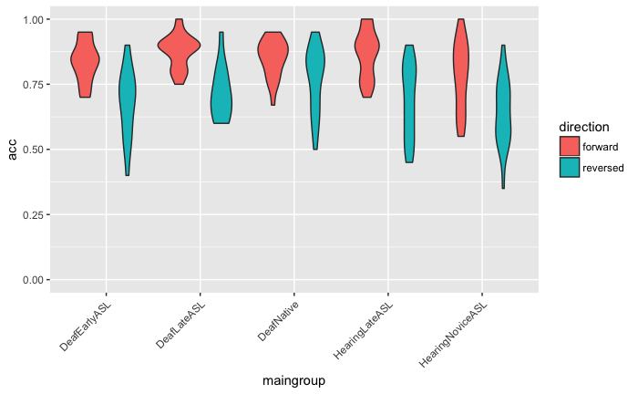

```r
# Summarizing means and SDs
accdata <- data %>%
  ungroup() %>%
  group_by(maingroup,direction) %>%
  dplyr::summarize(acc.mean = mean(acc, na.rm=TRUE),
            acc.sd = sd(acc, na.rm=TRUE))
#Violin plot
ggplot(data,aes(maingroup,acc,fill=direction)) +
  geom_violin() +
  scale_y_continuous(limits=c(0,1)) +
  theme(axis.text.x=element_text(angle=45,hjust=1))
```

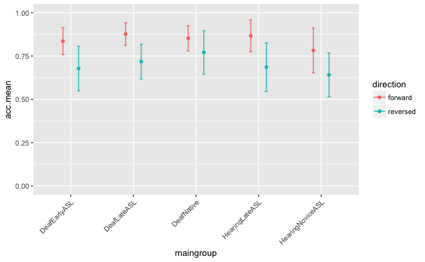

```r
# Error bar chart
ggplot(accdata,aes(maingroup,acc.mean,color=direction)) +
  geom_point(position=position_dodge(0.5)) +
  geom_errorbar(aes(ymin=acc.mean-acc.sd,ymax=acc.mean+acc.sd),width=0.1,position=position_dodge(0.5)) +
  scale_y_continuous(limits=c(0,1)) +
  theme(axis.text.x=element_text(angle=45,hjust=1))
```

# Group ANOVA

Let’s test for statistical significance. A simple ANOVA tell us there is a main effect of group and direction, but no interactions.

```r
# Let's set Deaf Native as the reference level to compare all other
data$maingroup <- relevel(data$maingroup, ref="DeafNative")
# Run the ANOVA
acc.anova <- aov(data=data,acc ~ maingroup*direction)
anova(acc.anova)
```

```
Analysis of Variance Table

Response: acc
                     Df  Sum Sq Mean Sq F value    Pr(>F)
maingroup             4 0.25883 0.06471  5.2652 0.0004781 ***
direction             1 1.03966 1.03966 84.5953 < 2.2e-16 ***
maingroup:direction   4 0.06437 0.01609  1.3094 0.2678884
Residuals           194 2.38421 0.01229
---
Signif. codes:  0 ‘***’ 0.001 ‘**’ 0.01 ‘*’ 0.05 ‘.’ 0.1 ‘ ’ 1
```

```r
# kable(tidy(acc.anova), digits=3) %>% kable_styling(bootstrap_options = c("striped", "hover", "condensed"))
```

Tukey’s HSD posthoc tells us that Hearing Novice ASL is significantly different from Deaf Native.

```r
# Run the posthoc on main group
acc.posthoc <- TukeyHSD(acc.anova,'maingroup',conf.level = 0.95)
acc.posthoc
```

```
  Tukey multiple comparisons of means
    95% family-wise confidence level

Fit: aov(formula = acc ~ maingroup * direction, data = data)

$maingroup
                                       diff         lwr           upr     p adj
DeafEarlyASL-DeafNative         -0.05435990 -0.12228806  0.0135682502 0.1827414
DeafLateASL-DeafNative          -0.01408101 -0.08571849  0.0575564659 0.9828866
HearingLateASL-DeafNative       -0.03505435 -0.09803939  0.0279306969 0.5426520
HearingNoviceASL-DeafNative     -0.09971344 -0.16408426 -0.0353426175 0.0002986
DeafLateASL-DeafEarlyASL         0.04027889 -0.03518395  0.1157417278 0.5833527
HearingLateASL-DeafEarlyASL      0.01930556 -0.04799844  0.0866095474 0.9333215
HearingNoviceASL-DeafEarlyASL   -0.04535354 -0.11395612  0.0232490455 0.3648014
HearingLateASL-DeafLateASL      -0.02097333 -0.09201925  0.0500725805 0.9264324
HearingNoviceASL-DeafLateASL    -0.08563242 -0.15790973 -0.0133551204 0.0112978
HearingNoviceASL-HearingLateASL -0.06465909 -0.12837091 -0.0009472717 0.0447976
```

```r
#kable(tidy(acc.posthoc), digits=3) %>% kable_styling(bootstrap_options = c("striped", "hover", "condensed"))
```

```r
#Coefficients
kable(tidy(acc.anova$coefficients), digits=3) %>% kable_styling(bootstrap_options = c("striped", "hover", "condensed"))
```

| names | x |
| --- | --- |
| (Intercept) | 0.852 |
| maingroupDeafEarlyASL | -0.016 |
| maingroupDeafLateASL | 0.024 |
| maingroupHearingLateASL | 0.014 |
| maingroupHearingNoviceASL | -0.070 |
| directionreversed | -0.082 |
| maingroupDeafEarlyASL:directionreversed | -0.077 |
| maingroupDeafLateASL:directionreversed | -0.077 |
| maingroupHearingLateASL:directionreversed | -0.099 |
| maingroupHearingNoviceASL:directionreversed | -0.060 |

# AoASL & Hearing ANCOVA

Let’s try ANCOVAs where we include AoASL and hearing status as predictors too - so now we’re not using MainGroups anymore. But we do have the AoASL-hearing collinearity problem. So. Let’s try it anyway. Plot first.

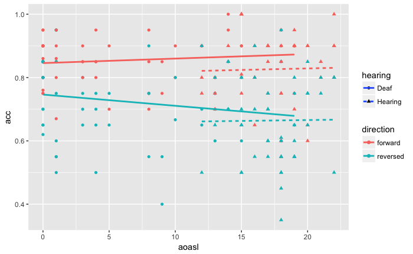

```r
ggplot(data, aes(x=aoasl,y=acc)) +
  geom_point(aes(color=direction,shape=hearing)) +
  geom_smooth(aes(color=direction,linetype=hearing),method="lm",se=FALSE)
```

And now the ANCOVA. I’m a bit surprised we’re not getting a direction:AoASL:hearing interaction because definitely we can see within the deaf group, there is a reversal effect correlated with AoASL. Maybe it’s because of the collinearity.

```r
acc.ancova <- aov(data=data,acc ~ direction * aoasl * hearing)
anova(acc.ancova)
```

```
Analysis of Variance Table

Response: acc
                         Df  Sum Sq Mean Sq F value    Pr(>F)
direction                 1 1.03966 1.03966 79.5814 3.283e-16 ***
aoasl                     1 0.07953 0.07953  6.0878   0.01447 *
hearing                   1 0.02473 0.02473  1.8933   0.17040
direction:aoasl           1 0.03649 0.03649  2.7933   0.09625 .
direction:hearing         1 0.00142 0.00142  0.1089   0.74171
aoasl:hearing             1 0.00181 0.00181  0.1386   0.71010
direction:aoasl:hearing   1 0.00287 0.00287  0.2196   0.63990
Residuals               196 2.56055 0.01306
---
Signif. codes:  0 ‘***’ 0.001 ‘**’ 0.01 ‘*’ 0.05 ‘.’ 0.1 ‘ ’ 1
```

In summary, ANOVA tells us there are main effects of group and direction, no interactions. The ANCOVA tells us we have a main effect of direction and AoASL, but not of hearing. All interesting.

# Item-Level Modeling

I’m curious if there’s any item-level effects we should be watching out for. Because there are 4 different stories. Let’s plot those out.

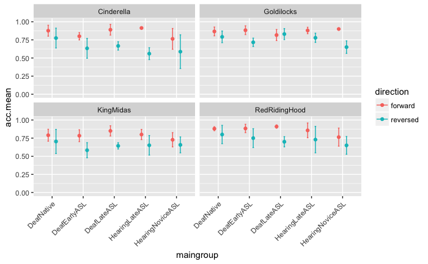

```r
# Run summary stats grouped by story, too
accdata2 <- data %>%
  group_by(maingroup,story,direction) %>%
  dplyr::summarize(acc.mean = mean(acc, na.rm=TRUE),
            acc.sd = sd(acc, na.rm=TRUE))
# Boxplot
# ggplot(data,aes(maingroup,acc,fill=direction)) +
#   geom_boxplot() +
#   scale_y_continuous(limits=c(0,1)) +
#   facet_wrap("story")
# Error bar chart
ggplot(accdata2,aes(maingroup,acc.mean,color=direction)) +
  geom_point(position=position_dodge(0.5)) +
  geom_errorbar(aes(ymin=acc.mean-acc.sd,ymax=acc.mean+acc.sd),width=0.1,position=position_dodge(0.5)) +
  scale_y_continuous(limits=c(0,1)) +
  facet_wrap("story") +
  theme(axis.text.x=element_text(angle=45,hjust=1))
```

Maybe we should put those in as random effects variables in a mixed model, along with participants too. With mixed models, you define predictor variables (what we’re interested in; aka, fixed effects) and grouping (what we’re not interested in, aka, random effects). This is overkill for simple accuracy data but this will help set us up for eye tracking analysis and **importantly reviewers may ask us about item-level effects given we have just 4 stories.**

So here, we have fixed effects of group and direction, and random effects of story and id, with varying slopes for direction.

The output tells us now that Hearing Novice ASL is significantly different from Deaf Native ASL, that we still have a main effect of direction, with a significant interaction of direction and Hearing Late ASL. We probably don’t need all this in the paper, though, the ANOVA will do and accuracy is not our main point.

```r
acc.lm <- lmer(data=data, acc ~ maingroup*direction + (direction|id) + (1|story))
summary(acc.lm)
```

```
Linear mixed model fit by REML t-tests use Satterthwaite approximations to degrees of freedom [lmerMod]
Formula: acc ~ maingroup * direction + (direction | id) + (1 | story)
   Data: data

REML criterion at convergence: -303.4

Scaled residuals:
     Min       1Q   Median       3Q      Max
-2.06851 -0.62549  0.04674  0.55393  2.30845

Random effects:
 Groups   Name              Variance Std.Dev. Corr
 id       (Intercept)       0.001767 0.04204
          directionreversed 0.002675 0.05172  0.21
 story    (Intercept)       0.001556 0.03945
 Residual                   0.007696 0.08773
Number of obs: 204, groups:  id, 52; story, 4

Fixed effects:
                                            Estimate Std. Error       df t value Pr(>|t|)
(Intercept)                                  0.85322    0.02955 11.56000  28.873  3.9e-12 ***
maingroupDeafEarlyASL                       -0.01581    0.03334 46.51000  -0.474  0.63762
maingroupDeafLateASL                         0.01819    0.03506 48.54000   0.519  0.60620
maingroupHearingLateASL                      0.01280    0.03089 46.65000   0.414  0.68053
maingroupHearingNoviceASL                   -0.07201    0.03161 46.76000  -2.278  0.02732 *
directionreversed                           -0.08475    0.02993 47.65000  -2.831  0.00677 **
maingroupDeafEarlyASL:directionreversed     -0.07618    0.04543 46.50000  -1.677  0.10026
maingroupDeafLateASL:directionreversed      -0.06757    0.04784 48.77000  -1.412  0.16419
maingroupHearingLateASL:directionreversed   -0.09478    0.04204 46.78000  -2.254  0.02889 *
maingroupHearingNoviceASL:directionreversed -0.05448    0.04308 46.85000  -1.265  0.21223
---
Signif. codes:  0 ‘***’ 0.001 ‘**’ 0.01 ‘*’ 0.05 ‘.’ 0.1 ‘ ’ 1

Correlation of Fixed Effects:
            (Intr) mnDEASL mnDLASL mnHLASL mnHNASL drctnr mDEASL: mDLASL: mHLASL:
mngrpDfEASL -0.491
mngrpDfLASL -0.468  0.410
mngrpHrLASL -0.531  0.467   0.450
mngrpHrNASL -0.519  0.455   0.442   0.499
dirctnrvrsd -0.335  0.296   0.284   0.321   0.314
mngrpDEASL:  0.220 -0.449  -0.180  -0.207  -0.201  -0.657
mngrpDLASL:  0.211 -0.180  -0.456  -0.205  -0.203  -0.628  0.404
mngrpHLASL:  0.239 -0.208  -0.206  -0.448  -0.227  -0.713  0.463   0.452
mngrpHNASL:  0.234 -0.201  -0.203  -0.227  -0.450  -0.696  0.449   0.445   0.501
```

Here are the coefficients in a nicer format.

```r
kable(xtable(coef(summary(acc.lm))), digits=3) %>% kable_styling(bootstrap_options = c("striped", "hover", "condensed"))
```

|  | Estimate | Std. Error | df | t value | Pr(>\|t\|) |
| --- | --- | --- | --- | --- | --- |
| (Intercept) | 0.853 | 0.030 | 11.558 | 28.873 | 0.000 |
| maingroupDeafEarlyASL | -0.016 | 0.033 | 46.514 | -0.474 | 0.638 |
| maingroupDeafLateASL | 0.018 | 0.035 | 48.543 | 0.519 | 0.606 |
| maingroupHearingLateASL | 0.013 | 0.031 | 46.652 | 0.414 | 0.681 |
| maingroupHearingNoviceASL | -0.072 | 0.032 | 46.761 | -2.278 | 0.027 |
| directionreversed | -0.085 | 0.030 | 47.647 | -2.831 | 0.007 |
| maingroupDeafEarlyASL:directionreversed | -0.076 | 0.045 | 46.502 | -1.677 | 0.100 |
| maingroupDeafLateASL:directionreversed | -0.068 | 0.048 | 48.765 | -1.412 | 0.164 |
| maingroupHearingLateASL:directionreversed | -0.095 | 0.042 | 46.778 | -2.254 | 0.029 |
| maingroupHearingNoviceASL:directionreversed | -0.054 | 0.043 | 46.849 | -1.265 | 0.212 |

# Group1/Group2 Differences?

One more thing I just remembered. What if a reviewer asks if Group 1 differed from Group 2 (in other words, was there an effect of stimulus order)? Easy to do now that our data is nicely organized (or “tidy”).

```r
acc.lm.order <- lm(data=data, acc ~ videogroup)
kable(tidy(summary(acc.lm.order)),digits=4)
```

| term | estimate | std.error | statistic | p.value |
| --- | --- | --- | --- | --- |
| (Intercept) | 0.7612 | 0.0140 | 54.2806 | 0.0000 |
| videogroupGroup 2 | 0.0162 | 0.0191 | 0.8464 | 0.3983 |

Good, good, no sig diff between groups.

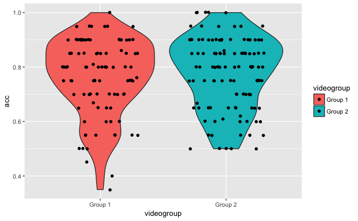

```r
ggplot(data, aes(x=videogroup, y=acc, fill=videogroup)) +
#  geom_point(position="jitter") +
  geom_violin() +
  geom_jitter(width=.3)
```

```r
# ggplot(filter(data,direction=="reversed"),aes(x=aoasl,y=acc)) +
#   geom_point() +
#   geom_smooth(method="lm")
```

```r
# aoa.model <- lm(acc ~ aoasl, data=filter(data,direction=="reversed"))
# summary(aoa.model)
```